# Labs 16-18

Dylan Maddux

2023-11-13

## Lab 16

## Question 1

```r
data("faithful")
fit <- lm(waiting ~ eruptions, data = faithful)
coef(fit)
```

```
## (Intercept)   eruptions
##    33.47440    10.72964
```

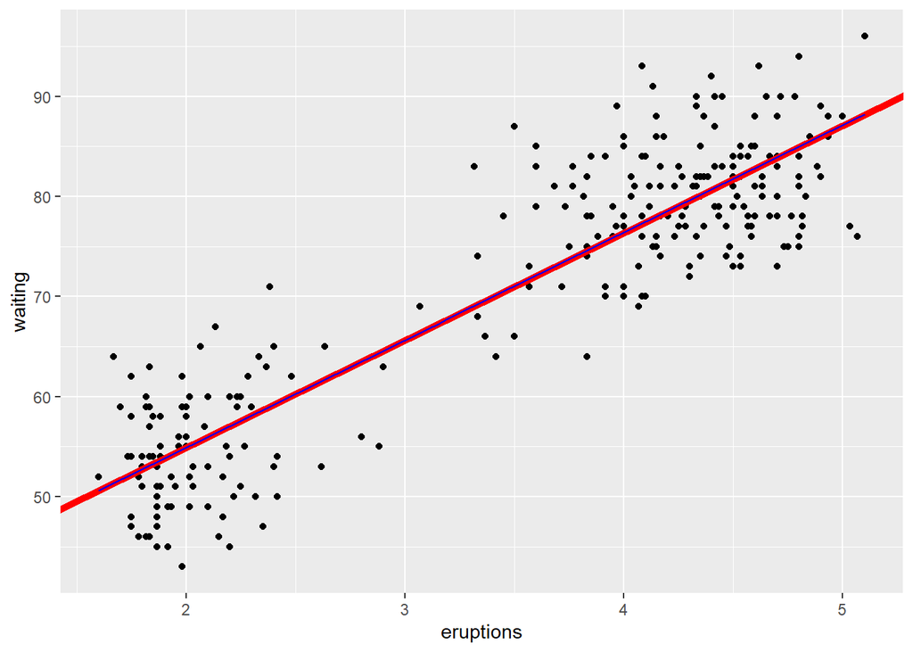

```r
ggplot(faithful, aes(eruptions, waiting)) + geom_point() +  geom_abline(intercept = 33.47440, slope = 10.72964, color = 'red', size = 2) +  geom_smooth(method = 'lm', color = 'blue', size = 0.5, se = FALSE)
```

## Question 3

```r
set.seed(123)
x <- rnorm(20)
y <- 2 - 3*x + rnorm(20)
df <- data.frame(x, y)

fit <- lm(y ~ x, df)

# However, we do need a data.frame for predict
newdf <- data.frame(x = seq(-2, 2, length.out = 20))

# This returns new values for each x
(yhat <- predict(fit, newdata = newdf))
```

```
##          1          2          3          4          5          6          7
##  8.1163540  7.4682985  6.8202430  6.1721875  5.5241320  4.8760766  4.2280211
##          8          9         10         11         12         13         14
##  3.5799656  2.9319101  2.2838546  1.6357991  0.9877436  0.3396881 -0.3083674
##         15         16         17         18         19         20
## -0.9564229 -1.6044784 -2.2525339 -2.9005894 -3.5486449 -4.1967004
```

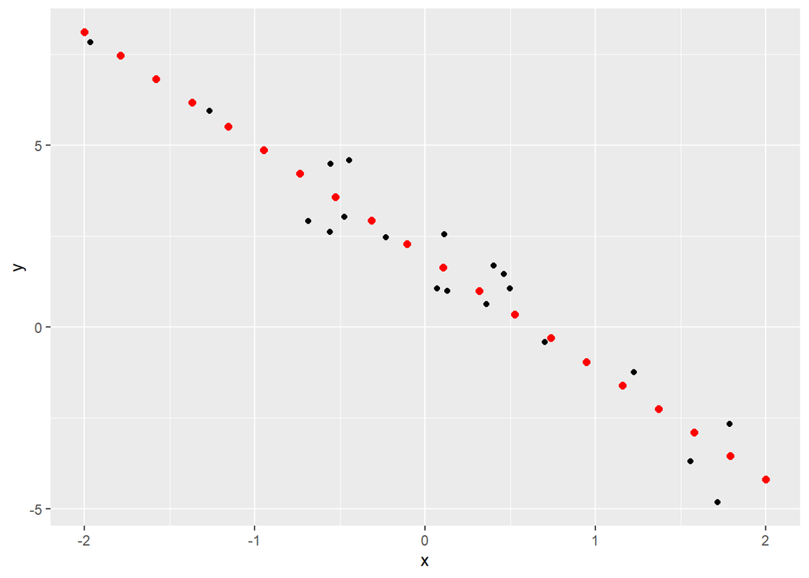

```r
newdf$y <- yhat

## The original data in black, predicted data in red
ggplot(df, aes(x, y)) + geom_point() +
  geom_point(data = newdf, mapping = aes(x, y), color = 'red', size = 2)
```

```r
(yhat <- predict(fit, newdata = newdf, interval = "prediction"))
```

```
##           fit        lwr        upr
## 1   8.1163540  6.0784060 10.1543021
## 2   7.4682985  5.4679372  9.4686598
## 3   6.8202430  4.8541935  8.7862925
## 4   6.1721875  4.2370006  8.1073744
## 5   5.5241320  3.6161912  7.4320729
## 6   4.8760766  2.9916084  6.7605448
## 7   4.2280211  2.3631096  6.0929325
## 8   3.5799656  1.7305706  5.4293605
## 9   2.9319101  1.0938892  4.7699309
## 10  2.2838546  0.4529881  4.1147210
## 11  1.6357991 -0.1921822  3.4637804
## 12  0.9877436 -0.8416420  2.8171291
## 13  0.3396881 -1.4953813  2.1747575
## 14 -0.3083674 -2.1533606  1.5366258
## 15 -0.9564229 -2.8155121  0.9026663
## 16 -1.6044784 -3.4817418  0.2727850
## 17 -2.2525339 -4.1519325 -0.3531353
## 18 -2.9005894 -4.8259477 -0.9752311
## 19 -3.5486449 -5.5036350 -1.5936547
## 20 -4.1967004 -6.1848303 -2.2085704
```

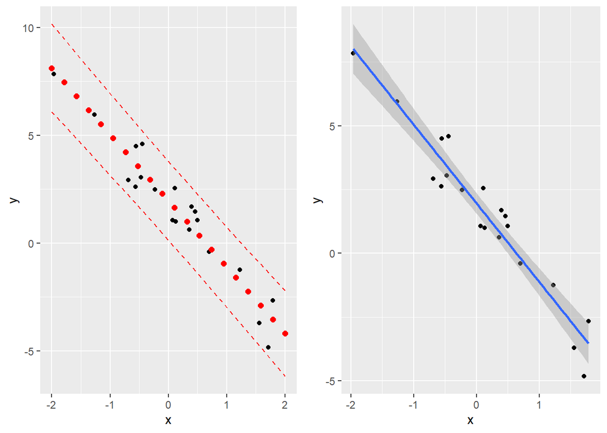

```r
yhat <- as.data.frame(yhat)
yhat$x <- newdf$x

# The pivot so that
library(tidyr)
yhat <- pivot_longer(yhat, cols = c("lwr", "upr"),
             names_to = "se", values_to = "values")

p1 <- ggplot(df, aes(x, y)) + geom_point() +
  geom_point(data = yhat, aes(x, fit), color = 'red', size = 2) +
  geom_line(data = yhat, aes(x, values, group = se), color = 'red',
            linetype = "dashed")

# Compare this with geom_smooth
p2 <- ggplot(df, aes(x, y)) + geom_point() +
  geom_smooth(method = "lm")

gridExtra::grid.arrange(p1, p2, nrow = 1)
```

The Confidence Interval Graph is relatively unaffected while the Standard Error Neighborhood is noticeably wider. The randomness of the 20 data points has a stronger affect on the graph due to the low sample size. Thus, any deviation from the predicted value affects the standard error more.

## Question 4

```r
set.seed(123)
x <- rnorm(100)
y <- 2 - 3*x + rnorm(100, sd = 5)
df <- data.frame(x, y)

fit <- lm(y ~ x, df)

# However, we do need a data.frame for predict
newdf <- data.frame(x = seq(-2, 2, length.out = 20))

# This returns new values for each x
(yhat <- predict(fit, newdata = newdf))
```

```
##          1          2          3          4          5          6          7
##  8.0107009  7.3238886  6.6370764  5.9502642  5.2634520  4.5766397  3.8898275
##          8          9         10         11         12         13         14
##  3.2030153  2.5162031  1.8293908  1.1425786  0.4557664 -0.2310458 -0.9178581
##         15         16         17         18         19         20
## -1.6046703 -2.2914825 -2.9782947 -3.6651070 -4.3519192 -5.0387314
```

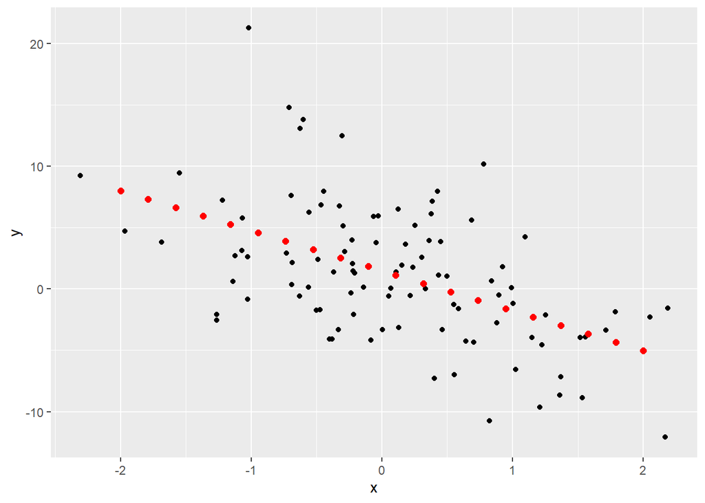

```r
newdf$y <- yhat

## The original data in black, predicted data in red
ggplot(df, aes(x, y)) + geom_point() +
  geom_point(data = newdf, mapping = aes(x, y), color = 'red', size = 2)
```

```r
(yhat <- predict(fit, newdata = newdf, interval = "prediction"))
```

```
##           fit        lwr       upr
## 1   8.0107009  -1.919701 17.941103
## 2   7.3238886  -2.559070 17.206847
## 3   6.6370764  -3.203276 16.477429
## 4   5.9502642  -3.852383 15.752911
## 5   5.2634520  -4.506448 15.033352
## 6   4.5766397  -5.165520 14.318800
## 7   3.8898275  -5.829643 13.609298
## 8   3.2030153  -6.498852 12.904883
## 9   2.5162031  -7.173175 12.205581
## 10  1.8293908  -7.852631 11.511412
## 11  1.1425786  -8.537232 10.822389
## 12  0.4557664  -9.226982 10.138515
## 13 -0.2310458  -9.921876  9.459784
## 14 -0.9178581 -10.621901  8.786185
## 15 -1.6046703 -11.327036  8.117695
## 16 -2.2914825 -12.037253  7.454288
## 17 -2.9782947 -12.752514  6.795925
## 18 -3.6651070 -13.472777  6.142563
## 19 -4.3519192 -14.197989  5.494151
## 20 -5.0387314 -14.928094  4.850632
```

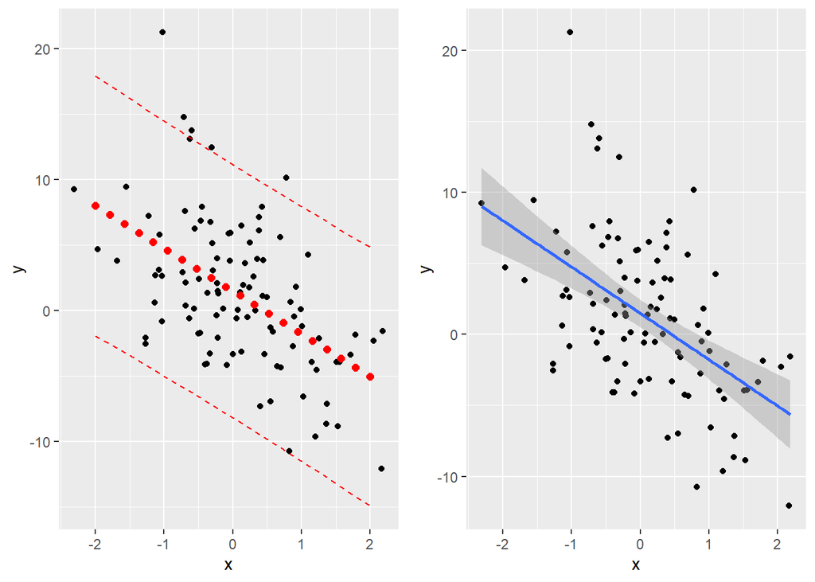

```r
yhat <- as.data.frame(yhat)
yhat$x <- newdf$x

# The pivot so that
library(tidyr)
yhat <- pivot_longer(yhat, cols = c("lwr", "upr"),
             names_to = "se", values_to = "values")

p1 <- ggplot(df, aes(x, y)) + geom_point() +
  geom_point(data = yhat, aes(x, fit), color = 'red', size = 2) +
  geom_line(data = yhat, aes(x, values, group = se), color = 'red',
            linetype = "dashed")

# Compare this with geom_smooth
p2 <- ggplot(df, aes(x, y)) + geom_point() +
  geom_smooth(method = "lm")

gridExtra::grid.arrange(p1, p2, nrow = 1)
```

An Increased Standard Deviation increases the width of the intervals. The two main sources of variability are the sample size and the standard deviation.

## Lab 17

## Question 1

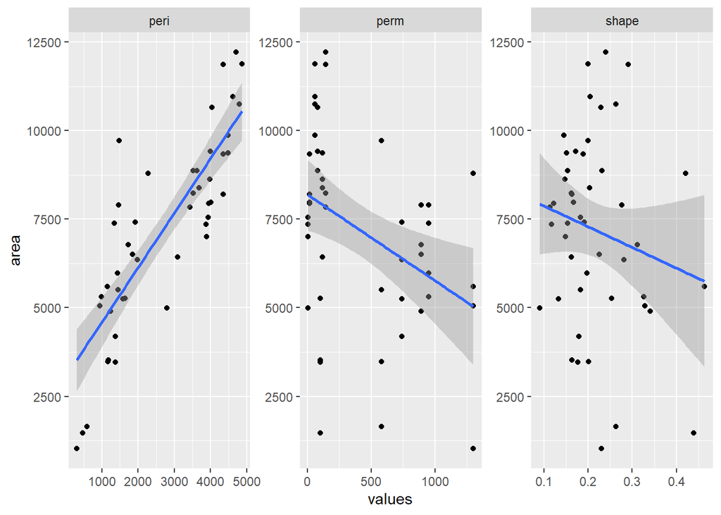

```r
data("rock")
decoster <- pivot_longer(rock, cols = c("peri","shape","perm"),
                         names_to = "attribute", values_to = "values")


ggplot(decoster, aes(values, area)) + geom_point() +
  facet_wrap(~attribute, scales = "free") +
  geom_smooth(method = "lm")
```

```r
fit <- lm(area ~ peri + perm + shape, rock)
summary(fit)
```

```
##
## Call:
## lm(formula = area ~ peri + perm + shape, data = rock)
##
## Residuals:
##     Min      1Q  Median      3Q     Max
## -3256.3  -781.9  -121.3   652.8  4788.3
##
## Coefficients:
##              Estimate Std. Error t value Pr(>|t|)
## (Intercept) -407.0690   919.8868  -0.443 0.660280
## peri           2.1934     0.1966  11.156 2.06e-14 ***
## perm           2.5492     0.6976   3.654 0.000684 ***
## shape       2992.3143  2735.3722   1.094 0.279937
## ---
## Signif. codes:  0 '***' 0.001 '**' 0.01 '*' 0.05 '.' 0.1 ' ' 1
##
## Residual standard error: 1300 on 44 degrees of freedom
## Multiple R-squared:  0.7805, Adjusted R-squared:  0.7655
## F-statistic: 52.14 on 3 and 44 DF,  p-value: 1.561e-14
```

It appears that perimeter has the strongest linear relationship with area. y-hat = -407.07 + 2.19X1 + 2.55X2 + 2992.31X3 Where X1 is peri, X2 is perm, and X3 is shape The variable with the largest r-squared value was perimeter with 0.6 like we predicted.

## Question 2

```r
colleges <- read.csv("https://remiller1450.github.io/data/Colleges2019.csv")
colleges <- na.omit(colleges)
fitall <- lm(Salary10yr_median ~ Adm_Rate + Debt_median + Avg_Fac_Salary + ACT_median + Net_Tuition, colleges)
analysis1 <- summary(fitall)

#fit1 <- lm(Salary10yr_median ~ Adm_Rate, colleges)
#analysis2 <- summary(fit1)

#fit2 <- lm(Salary10yr_median ~ Adm_Rate + Debt_median, colleges)
#analysis3 <- summary(fit2)

fit3 <- lm(Salary10yr_median ~ Adm_Rate + Debt_median + ACT_median, colleges)
analysis4 <- summary(fit3)

#plot(colleges$Avg_Fac_Salary, residuals(fit2), main = "Average Faculty Salary vs Residuals")

#analysis1
#analysis1 <- anova(fitch)
analysis4
```

```
##
## Call:
## lm(formula = Salary10yr_median ~ Adm_Rate + Debt_median + ACT_median,
##     data = colleges)
##
## Residuals:
##    Min     1Q Median     3Q    Max
## -22294  -4761   -620   3494  70495
##
## Coefficients:
##               Estimate Std. Error t value Pr(>|t|)
## (Intercept) -3.217e+03  2.406e+03  -1.337    0.181
## Adm_Rate    -5.565e+03  1.400e+03  -3.975  7.5e-05 ***
## Debt_median  5.500e-01  6.475e-02   8.494  < 2e-16 ***
## ACT_median   1.834e+03  7.708e+01  23.789  < 2e-16 ***
## ---
## Signif. codes:  0 '***' 0.001 '**' 0.01 '*' 0.05 '.' 0.1 ' ' 1
##
## Residual standard error: 7946 on 1091 degrees of freedom
## Multiple R-squared:  0.4864, Adjusted R-squared:  0.485
## F-statistic: 344.4 on 3 and 1091 DF,  p-value: < 2.2e-16
```

Our linear models include the variables Admission Rate, Debt Median, and ACT median which all increase the accuracy of our linear model by a significant amount: y-hat = -3217 - 5565 X1 + 0.55 X2 + 1834 X3 where X1 = Admission rate, X2 is Debt median, and X3 is ACT Median

## Question 3

```r
#Relationship between weight and miles per gallon with carburators as integer/factor
data(mtcars)
fit <- lm(mpg ~ wt + as.factor(carb), mtcars)
fit2 <- lm(mpg ~ wt + carb, mtcars)
summary(fit)
```

```
##
## Call:
## lm(formula = mpg ~ wt + as.factor(carb), data = mtcars)
##
## Residuals:
##    Min     1Q Median     3Q    Max
## -4.559 -1.791  0.000  1.413  5.719
##
## Coefficients:
##                  Estimate Std. Error t value Pr(>|t|)
## (Intercept)       36.8336     2.0998  17.542 1.45e-15 ***
## wt                -4.6148     0.7059  -6.537 7.57e-07 ***
## as.factor(carb)2  -1.2225     1.5205  -0.804    0.429
## as.factor(carb)3  -2.7206     2.3093  -1.178    0.250
## as.factor(carb)4  -3.0580     1.7972  -1.702    0.101
## as.factor(carb)6  -4.3507     3.2547  -1.337    0.193
## as.factor(carb)8  -5.3589     3.3369  -1.606    0.121
## ---
## Signif. codes:  0 '***' 0.001 '**' 0.01 '*' 0.05 '.' 0.1 ' ' 1
##
## Residual standard error: 3.039 on 25 degrees of freedom
## Multiple R-squared:  0.795,  Adjusted R-squared:  0.7458
## F-statistic: 16.16 on 6 and 25 DF,  p-value: 1.605e-07
```

```r
summary(fit2)
```

```
##
## Call:
## lm(formula = mpg ~ wt + carb, data = mtcars)
##
## Residuals:
##     Min      1Q  Median      3Q     Max
## -4.5206 -2.1223 -0.0467  1.4551  5.9736
##
## Coefficients:
##             Estimate Std. Error t value Pr(>|t|)
## (Intercept)  37.7300     1.7602  21.435  < 2e-16 ***
## wt           -4.7646     0.5765  -8.265 4.12e-09 ***
## carb         -0.8215     0.3492  -2.353   0.0256 *
## ---
## Signif. codes:  0 '***' 0.001 '**' 0.01 '*' 0.05 '.' 0.1 ' ' 1
##
## Residual standard error: 2.839 on 29 degrees of freedom
## Multiple R-squared:  0.7924, Adjusted R-squared:  0.7781
## F-statistic: 55.36 on 2 and 29 DF,  p-value: 1.255e-10
```

1. When treating carburetor as an integer, the model predicts the mpg based on how many carburaters were addded, specifically it predicts a 0.82 decrease in mpg per carburetor added. The factor model looks at each individual carburetor count and then sees how much that count affects the mpg amount compared to 1 carburetor as a baseline.
2. There are only a few cars that have 3, 4, 6… carburetors individually. Thus the factor model has a smaller sample size to work with compared to the numeric model which can use every car in the data set. We also noticed the factor model better predicts the addition of carburetors when the current carburater count is high (extra carburetors have less of an impact at higher quantities).

H0 factor: The carburetor quantity does not correlate significantly with mpg in comparison to 1 carburetor.

## Lab 18

## Question 1

1. We predict that an average there will be 6 successes and 4 failure if we play 10 times
2. The probability is 6/(6+4) = 6/10 = 60% chance of success
3. 12 wins and 4 success means the odds are 12/16 which is a 75% change of winning
4. Halving the odds means 3 to 4 which a 3/7 odds.
5. The range of a probability is between 0 and 1, thus there are no positive number to multiply the odds to get a number greater than 1 or lower than 0

```r
Donner <- read.csv("https://collinn.github.io/data/donner.csv")
head(Donner)
```

```
##   age        y    sex family.name status
## 1  13 survived   Male       Breen Family
## 2   1 survived Female       Breen Family
## 3   5 survived   Male       Breen Family
## 4  14 survived   Male       Breen Family
## 5  40 survived Female       Breen Family
## 6  51 survived   Male       Breen Family
```

```r
dat <- mutate(Donner,
              death = ifelse(y == "died", 1, 0)) %>%
  na.omit()

fit_log <- glm(death ~ sex + age, data = dat, family = "binomial")

#summary(fit_log)


fit_lin <- lm(death ~ sex + age + status, data = dat)

summary(fit_lin)
```

```
##
## Call:
## lm(formula = death ~ sex + age + status, data = dat)
##
## Residuals:
##     Min      1Q  Median      3Q     Max
## -0.6597 -0.3686 -0.1981  0.3863  0.8272
##
## Coefficients:
##              Estimate Std. Error t value Pr(>|t|)
## (Intercept)  0.166509   0.097422   1.709   0.0912 .
## sexMale      0.158185   0.110348   1.434   0.1555
## age          0.006311   0.003203   1.971   0.0521 .
## statusHired  0.145710   0.140499   1.037   0.3027
## statusSingle 0.479662   0.226125   2.121   0.0369 *
## ---
## Signif. codes:  0 '***' 0.001 '**' 0.01 '*' 0.05 '.' 0.1 ' ' 1
##
## Residual standard error: 0.464 on 83 degrees of freedom
## Multiple R-squared:  0.177,  Adjusted R-squared:  0.1373
## F-statistic: 4.463 on 4 and 83 DF,  p-value: 0.002574
```

## Quesiton 2

1. 0.48 * 1 + 0.158 * 1 + 0.0063 * 35 + 0.1665 = 1.025
2. This is not a valid likely because we are using a linear model instead of a logarithmic or logistic who’s derivative is close to 0 at f(x) = 1
3. Logistic regression never has values that reach over 1, thus it could not.

## Question 3

```r
gsw <- read.csv("https://remiller1450.github.io/data/GSWarriors.csv")
gsw$win_binary <- ifelse(gsw$Win == "W", 1, 0)
gsw_fit <- glm(win_binary ~ FG3A, data = gsw, family = "binomial")
summary(gsw_fit)
```

```
##
## Call:
## glm(formula = win_binary ~ FG3A, family = "binomial", data = gsw)
##
## Coefficients:
##             Estimate Std. Error z value Pr(>|z|)
## (Intercept)  1.02624    1.90428   0.539    0.590
## FG3A         0.03426    0.06098   0.562    0.574
##
## (Dispersion parameter for binomial family taken to be 1)
##
##     Null deviance: 56.745  on 81  degrees of freedom
## Residual deviance: 56.423  on 80  degrees of freedom
## AIC: 60.423
##
## Number of Fisher Scoring iterations: 5
```

```r
exp(coef(gsw_fit))
```

```
## (Intercept)        FG3A
##    2.790563    1.034856
```

1. After exponentiation the Intercept is 2.791 and FG3A 1.035. Everytime we have a 3 point attemp, our odds of winning increase by 1.035

```r
gsw_fit <- glm(win_binary ~ FG3A + FG3, data = gsw, family = "binomial")
summary(gsw_fit)
```

```
##
## Call:
## glm(formula = win_binary ~ FG3A + FG3, family = "binomial", data = gsw)
##
## Coefficients:
##             Estimate Std. Error z value Pr(>|z|)
## (Intercept)  0.93957    2.02162   0.465  0.64210
## FG3A        -0.10074    0.07754  -1.299  0.19386
## FG3          0.36516    0.13951   2.617  0.00886 **
## ---
## Signif. codes:  0 '***' 0.001 '**' 0.01 '*' 0.05 '.' 0.1 ' ' 1
##
## (Dispersion parameter for binomial family taken to be 1)
##
##     Null deviance: 56.745  on 81  degrees of freedom
## Residual deviance: 48.043  on 79  degrees of freedom
## AIC: 54.043
##
## Number of Fisher Scoring iterations: 6
```

```r
exp(coef(gsw_fit))
```

```
## (Intercept)        FG3A         FG3
##   2.5588879   0.9041642   1.4407382
```

2. Since all the other variables are held constant, notice that this model considers 3 pointers attempted when 3 pointer made are held constant. The reason FG3A is less than 1 is that when we score the same amount of 3s but take many shots, our efficiency is poor and thus our winning outcome is lower.

## Question 4

```r
(newdat <- dat[c(12, 37, 45), ])
```

```
##    age        y    sex family.name status death
## 12  45     died Female    J_Donner Family     1
## 37  57     died   Male      Graves Family     1
## 45  27 survived   Male       Hired  Hired     0
```

```r
fit <- glm(death ~ sex + age, data = dat, family = "binomial")
newdat$prob_death <- predict(fit, newdat, type = "response")
newdat <- newdat %>%
  mutate(classify_dead = as.numeric(prob_death >= 0.6))
sum(newdat$death == newdat$classify_dead) / nrow(newdat)
```

```
## [1] 0.3333333
```

```r
yhat <- ifelse(fitted(fit) > 0.6, 1, 0)
mean(dat$death == yhat)
```

```
## [1] 0.6022727
```

```r
yhat <- ifelse(yhat == 0, "survived", "died")
table(dat$y, yhat)
```

```
##           yhat
##            died survived
##   died       12       27
##   survived    8       41
```

```r
newdat2 <- newdat %>%
  mutate(classify_dead = as.numeric(prob_death >= 0.4))
sum(newdat2$death == newdat$classify_dead) / nrow(newdat2)
```

```
## [1] 0.3333333
```

```r
yhat <- ifelse(fitted(fit) > 0.4, 1, 0)
mean(dat$death == yhat)
```

```
## [1] 0.625
```

```r
yhat <- ifelse(yhat == 0, "survived", "died")
table(dat$y, yhat)
```

```
##           yhat
##            died survived
##   died       29       10
##   survived   23       26
```

For the 60% survival threshold model: Accuracy of predicting death = 12/39 = 30.7% Accuracy of predicting surviving = 41/49 = 83.6% Total accuracy of model = 53/88 = 60.2%

If we want to predict someone dying with high accuracy (with overall accuracy being not important) than the 40% survival threshold model should be the model we want to choose

## Question 5

We want everyone who has the disease to test positive and some false positives are okay. Even though model B has a lower accuracy it will correctly identify all the true positives while Test A has false negatives which are dangerous. The most important metric is to have the false negative rate to be zero (which Test B has). The test with a higher sensitivity is more useful in this example.

## Question 7

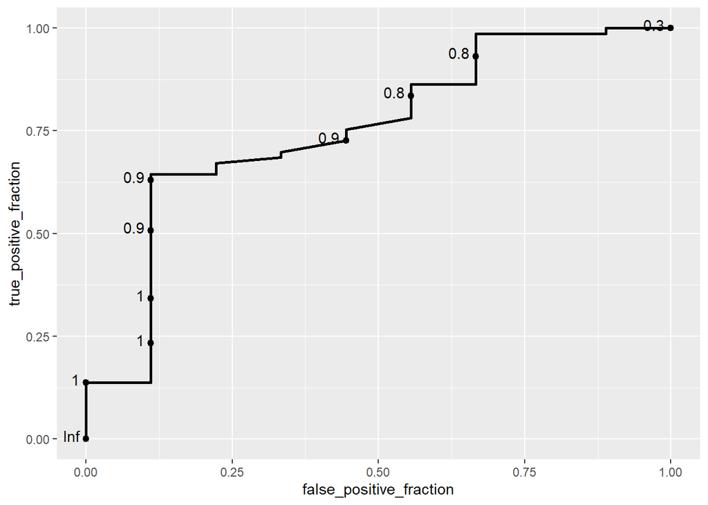

```r
gsw <- read.csv("https://remiller1450.github.io/data/GSWarriors.csv")
gsw$win_binary <- ifelse(gsw$Win == "W", 1, 0)
gsw_fit1 <- glm(win_binary ~ FG3A + FG3, data = gsw, family = "binomial")
gsw_fit2 <- glm(win_binary ~ FG3A, data = gsw, family = "binomial")
#summary(gsw_fit)
gsw$fitval1 <- fitted(gsw_fit1)
gsw$fitval2 <- fitted(gsw_fit2)
gswfgt <- ggplot(gsw) + geom_roc(aes(d = win_binary, m = fitval1))
gswfga <- ggplot(gsw) + geom_roc(aes(d = win_binary, m = fitval2))

ggplot(gsw) + geom_roc(aes(d = win_binary, m = fitval1))
```

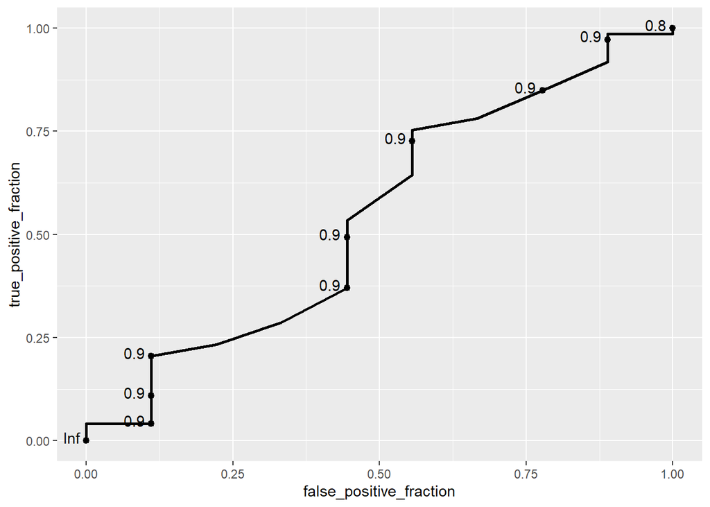

```r
ggplot(gsw) + geom_roc(aes(d = win_binary, m = fitval2))
```

```r
calc_auc(gswfgt)
```

```
##   PANEL group       AUC
## 1     1    -1 0.7526636
```

```r
calc_auc(gswfga)
```

```
##   PANEL group      AUC
## 1     1    -1 0.543379
```

The model considering both 3-pointers attempted is a more accurate model from the roc-curve compared to the one only considering attempts. The Auc for the model considering both is approx 0.75. while the model considering only attempts is 0.54.